# Packages

**R packages instalation**

Make sure to have all packages bellow instaled before reproducing the analysis. To install these packages, one can use the function `install.packages()`. However, for installing the INLA package, we recommend following the instruction provided the [INLA website](https://www.r-inla.org/download-install).

```r
library(tidyverse)
library(ggdist)
library(rgdal)
library(spdep)
library(INLA)
library(distributional)
library(viridis)
library(lubridate)
library(lemon)
library(ggthemes)
library(cowplot)
```

# Load SBR data

The data on SBR occurrences in Southern Brazil can be loaded as shown in the code chunk below. Notice that we performed the transformation on the type date column types to `date` format. The column `season` was also transformed to type `character`.

```r
sbr_rep = read.csv(".data/sbr_rep.csv") %>%
  #removing ther X column
  dplyr::select(-X) %>%

  # tranforming the date columns to type date
  mutate(start_season = as.Date(start_season),
         start_date = as.Date(start_date),
         date_report = as.Date(date_report)) %>%
  # tranforming the seasons column to type character
  mutate(season = as.character(season))
```

# Summaries SBR occurrence

In this part we extract some sumaries from the SBR data set

### Number of reports

```r
sbr_rep %>%
  summarise(n_reports = length(date_report))
```

| n_reports |
| --- |
| 2441 |

### Number of reports by state

```r
sbr_rep %>%
  group_by(state) %>%
  summarise(n_reports = length(date_report))
```

| state | n_reports |
| --- | --- |
| PR | 1239 |
| RS | 969 |
| SC | 233 |

```r
sbr_rep %>%
  group_by(state) %>%
  summarise(length(unique(location)))
```

| state | length(unique(location)) |
| --- | --- |
| PR | 278 |
| RS | 269 |
| SC | 87 |

### Number of reports by season

```r
sbr_rep %>%
  group_by(season) %>%
  summarise(n_reports = length(date_report)) %>%
  arrange(n_reports)
```

| season | n_reports |
| --- | --- |
| 2012 | 27 |
| 2014 | 60 |
| 2020 | 70 |
| 2013 | 105 |
| 2019 | 119 |
| 2016 | 121 |
| 2021 | 121 |
| 2017 | 124 |
| 2018 | 161 |
| 2011 | 168 |

[output cut: 7 more lines]

### Earliests reports per season

```r
sbr_rep %>%
  group_by(season) %>%
  filter(date_report == min(date_report)) %>%
  arrange(days_sep15)
```

```
# A tibble: 22 x 15
# Groups:   season [17]
   start_date season state location date_report Phen_state month  days   lat
   <date>     <chr>  <chr> <chr>    <date>      <chr>      <chr> <int> <dbl>
 1 2009-10-07 2010   PR    Londrina 2009-09-29  Vn         Sep       8 -23.3
 2 2018-09-07 2019   PR    Marecha~ 2018-10-31  R1         Oct      54 -24.6
 3 2012-08-07 2013   SC    São Car~ 2012-11-02  R2         Nov      87 -27.1
 4 2015-09-21 2016   PR    Ponta G~ 2015-11-07  R1         Nov      47 -25.1
 5 2005-08-07 2006   PR    Cafelân~ 2005-11-09  R3         Nov      94 -24.6
 6 2005-09-07 2006   PR    Campo M~ 2005-11-09  R2         Nov      63 -24.0
 7 2005-11-07 2006   PR    Cruzeir~ 2005-11-09  R4         Nov       2 -23.8
 8 2005-11-07 2006   PR    Mariluz  2005-11-09  R5         Nov       2 -24.0
 9 2006-11-07 2007   PR    Marecha~ 2006-11-14  V3         Nov       7 -24.6
10 2016-09-21 2017   PR    Boa Esp~ 2016-11-16  R3         Nov      56 -24.2
# ... with 12 more rows, and 6 more variables: lon <dbl>, Phen_state_int <int>,
#   start_season <date>, days_sep15 <int>, week <int>, region <chr>
```

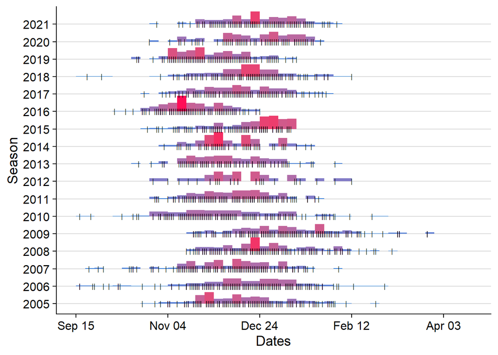

```r
sbr_rep %>%
  mutate(year_s = as.numeric(season)-2000,
         year_date = year(date_report),
         year_new = year_date-year_s,
         month2 = month(date_report),
         day = day(date_report)) %>%
  unite(date_altered, year_new, month2, day, sep ="-") %>%
  mutate(date_altered = as.Date(date_altered)) %>%
  ggplot(aes(y= season, x = days)) +
  stat_histinterval(aes(fill = stat(pdf)),
                    slab_type = "histogram",
                    geom = "slab",
                    breaks = 20
                    )+
  geom_point(shape = "|", size =2)+
  theme_half_open()+
  background_grid(major = "y")+
  scale_x_continuous(limits = c(0,215),
                     labels = format(as.Date(c(seq(0,215, by = 50)+as.Date("2000-09-15")),
                               format = "%d-%b-%Y"),"%b %d")
                     )+
  scale_fill_gradient(low ="#1e88e5ff", high = "#ff0d57ff")+
  labs(x = "Dates",
       y = "Season")+

  theme(axis.text.x = element_text(),
        strip.background = element_blank(),
        legend.position = "none"
        )
```

```r
ggsave(".figs/histogram_dates.png", dpi = 600, height = 10, width = 6)
```

# ENSO

## Load ENSO data

Here we load the data on Oceanic Niño Index (ONI)

```r
ensodata2 =read.csv( ".data/enso_tidy.csv") %>%
  #removing ther X column
  dplyr::select(-X) %>%
  # reodering the enso column as "Neutral" > "El Niño" > "La Niña"
  mutate(enso = factor(enso, c("Neutral","El Niño", "La Niña"))) %>%
  # tranforming the seasons column to type character
  mutate(season = as.character(season))
```

## Exploring ENSO data

```r
ONI_trimesters = ensodata2 %>%
  pivot_longer(1:12,
               names_to = "trimester",
               values_to = "ONI") %>%
  mutate(trimester = factor(trimester,
                            levels =c("DJF","JFM","FMA","MAM","AMJ","MJJ","JJA","JAS","ASO","SON","OND","NDJ" ) ))
ONI_trimesters
```

| season | enso | trimester | ONI |
| --- | --- | --- | --- |
| 2005 | El Niño | DJF | 0.4 |
| 2005 | El Niño | JFM | 0.3 |
| 2005 | El Niño | FMA | 0.2 |
| 2005 | El Niño | MAM | 0.2 |
| 2005 | El Niño | AMJ | 0.2 |
| 2005 | El Niño | MJJ | 0.3 |
| 2005 | El Niño | JJA | 0.5 |
| 2005 | El Niño | JAS | 0.6 |
| 2005 | El Niño | ASO | 0.7 |
| 2005 | El Niño | SON | 0.7 |

[output cut: 194 more lines]

### ONI over time for each year (2004 to 2020)

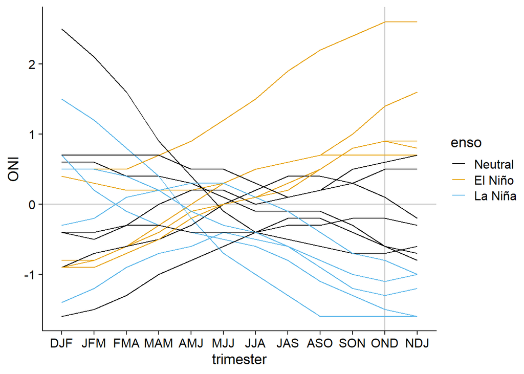

```r
ONI_trimesters %>%
  ggplot(aes(trimester, ONI, group = season, color = enso))+
  geom_hline(yintercept = 0, color = "gray")+
  scale_color_colorblind()+
  geom_vline(xintercept = "OND", color = "gray")+
stat_summary(fun.y=sum, geom="line")+
  theme_half_open()
```

### ONI for selected trimesters

- January, February, and March (ONI<sub>JFM</sub>, prior to the growing season);
- May, June, and July (ONI<sub>MJJ</sub>, prior to the growing season);
- October, November, and December (ONI<sub>OND</sub>, within the growing season)

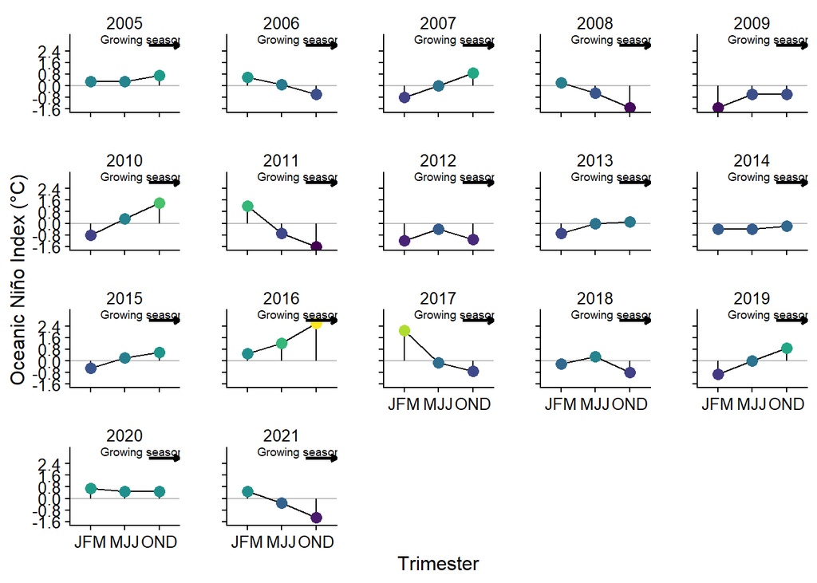

```r
ONI_trimesters %>%
  filter(trimester %in% c("JFM", "MJJ", "OND")) %>%
  ggplot(aes( trimester, ONI, group = trimester, color = ONI))+
  geom_hline(yintercept = 0, color = "gray")+
  geom_errorbar(aes(ymin=0, ymax  = ONI), width = 0, color = "black")+
  geom_line(aes(group = season), color="black")+
  geom_point(size = 3)+

  geom_segment(x = 2.7, y = 2.8, xend = 3.6, yend =2.8,
               color = "black",
               size =1,
               arrow = arrow(length = unit(0.09, "npc")))+
  annotate(geom ="text", x = 2.5, y =3.25 ,label = "Growing season", size = 2.5)+
  scale_y_continuous(breaks = seq(-1.6, 2.4, by  = 0.8))+
  scale_color_viridis()+
  theme_half_open(font_size = 12)+
  facet_rep_wrap(~season)+
  labs(x = "Trimester",
       y = "Oceanic Niño Index (°C)",
       color = "ENSO phase (OND)")+
  theme(strip.background = element_blank(),

        legend.position = "none")
```

```r
ggsave(".figs/ONItrimeter.png", dpi = 600, height = 6.5, width = 9, bg = "white")
```

### ONI distribution per trimester

- ONI values arranged from lowest to highest

```r
ONI_trimesters%>%
  filter(trimester %in% c("JFM", "MJJ", "OND")) %>%
  arrange(ONI)
```

| season | enso | trimester | ONI |
| --- | --- | --- | --- |
| 2011 | La Niña | OND | -1.6 |
| 2008 | La Niña | OND | -1.5 |
| 2009 | Neutral | JFM | -1.5 |
| 2021 | La Niña | OND | -1.3 |
| 2012 | La Niña | JFM | -1.2 |
| 2012 | La Niña | OND | -1.1 |
| 2019 | El Niño | JFM | -0.9 |
| 2007 | El Niño | JFM | -0.8 |
| 2010 | El Niño | JFM | -0.8 |
| 2018 | La Niña | OND | -0.8 |

[output cut: 41 more lines]

- Boxplot

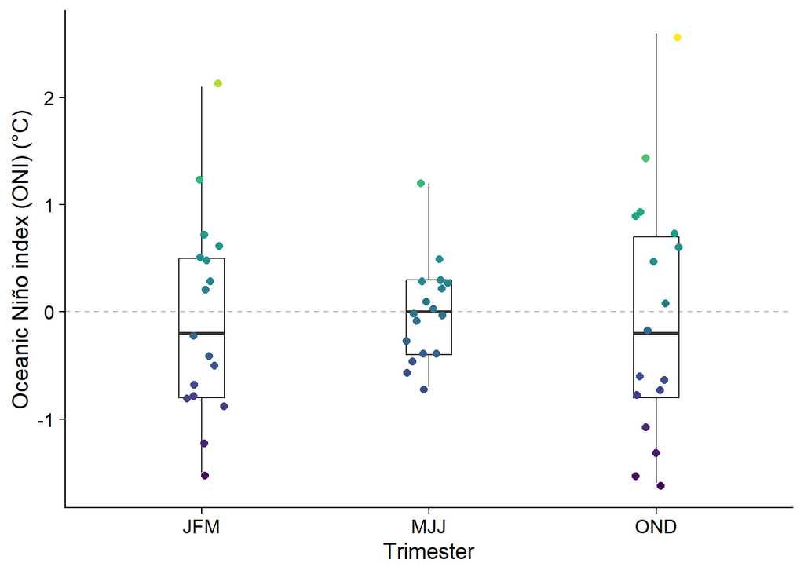

```r
ONI_trimesters%>%
  filter(trimester %in% c("JFM", "MJJ", "OND")) %>%
  ggplot(aes(trimester, ONI, color = ONI))+
  geom_hline(yintercept = 0, linetype = 2, color="gray")+
  geom_boxplot(width = 0.2, alpha =0)+
  geom_jitter(width = 0.1, size =2)+
  scale_color_viridis()+
  theme_half_open()+
  labs(x = "Trimester",
       y = "Oceanic Niño index (ONI) (°C)")+
  theme(legend.position = "none")
```

```r
ggsave(".figs/ONIbox_plot.png", dpi = 600, height = 4, width = 4, bg = "white")
```

- Summaries

```r
ONI_trimesters%>%
  filter(trimester %in% c("JFM", "MJJ", "OND")) %>%
  group_by(trimester) %>%
  summarise(ONI_mean = round(mean(ONI),2),
            ONI_sd = round(sd(ONI),2),
            median(ONI),
            min(ONI),
            max(ONI))
```

| trimester | ONI_mean | ONI_sd | median(ONI) | min(ONI) | max(ONI) |
| --- | --- | --- | --- | --- | --- |
| JFM | -0.05 | 0.94 | -0.2 | -1.5 | 2.1 |
| MJJ | -0.01 | 0.47 | 0.0 | -0.7 | 1.2 |
| OND | -0.04 | 1.15 | -0.2 | -1.6 | 2.6 |

# Modeling the effect of ONI

## Cox Proportional Hazards Model

### Data preparation

#### SBR data

```r
sbr_rep_count = sbr_rep %>%
  mutate(count =  1) %>%
  mutate(season = as.character(season))
```

#### Loading shapefiles

Shape files will be used for the obtaining the spatial structure of municipalities

```r
shape_sul= readOGR(".shapefiles/BR_MUN1997_S_region","BR_MUN1997_S_region" )
shape_sul@data$id = rownames(shape_sul@data)
sul_points = fortify(shape_sul)
sul_df =plyr::join(sul_points, shape_sul@data, by="id")
```

Obtaining the names of the municipalities from the shape files (formatting in the municipalies names in SBR dataset and shape files were different).

```r
IDs = unique(sul_df$id)
location2 = numeric(length(sbr_rep_count$lat))
for(i in 1:length(IDs)){
 qqq = sul_df %>%
  filter(id == IDs[i])

city = as.character(unique(qqq$MUNIC_PIO))

 for(j in 1:length(sbr_rep_count$lat)){
    pip = point.in.polygon(point.x = sbr_rep_count$lon[j],
                           point.y = sbr_rep_count$lat[j],
                           pol.x = qqq$long,
                           pol.y = qqq$lat)

      if(pip > 0){location2[j] = city}

 }
}
sbr_rep_count_new = sbr_rep_count %>%
  mutate(MUNIC_PIO = location2)
```

#### INLA Data

Creating the data set with new municipalities names

```r
months = c("Sep", "Oct", "Nov", "Dec", "Jan", "Feb", "Mar","Apr","May")
inla_data_geral = sbr_rep_count %>%
  mutate(month = factor(month, levels = months)) %>%
  full_join(sbr_rep_count_new %>% mutate(month = factor(month, levels = months))) %>%
  full_join(data.frame(MUNIC_PIO = unique(sbr_rep_count_new$MUNIC_PIO)) %>%
  mutate(S = 1:length(MUNIC_PIO)))
```

#### adding ONI values

```r
inla_data_enso = inla_data_geral %>%
  full_join(ensodata2)
```

#### Neighbour by distance 200 km

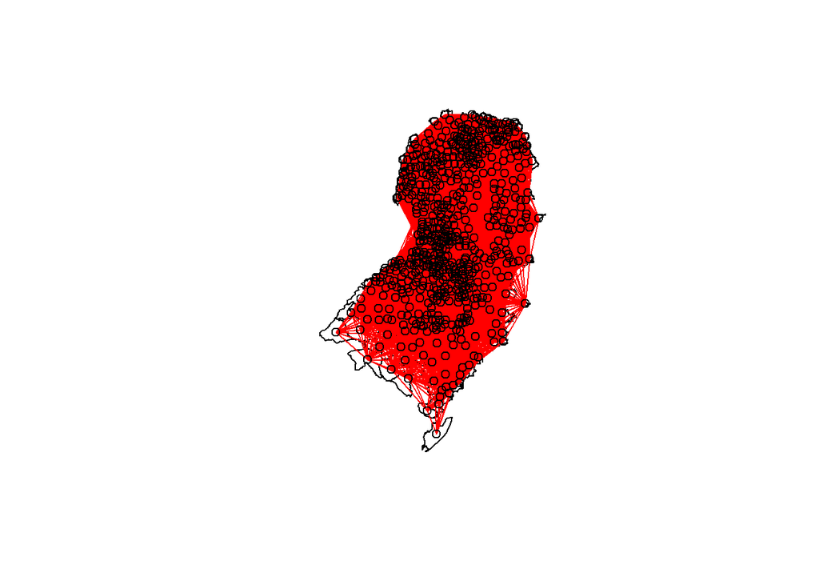

```r
sul_locations = unique(sbr_rep_count_new$MUNIC_PIO)

shape_sul_sub = subset(shape_sul, shape_sul$MUNIC_PIO%in%sul_locations )

coords_pr = coords <- coordinates(shape_sul_sub)

IDs_pr <- row.names(as(shape_sul_sub, "data.frame"))

long = coords_pr[,1]
lat = coords_pr[,2]
xy <- data.frame(ID = 1:(length(lat)), long, lat)

coordinates(xy) <- c("long", "lat")
proj4string(xy) <- CRS("+init=epsg:4326")

res <- spTransform(xy, CRS("+proj=utm +zone=22 +south ellps=WGS84"))
coords_grid = as.data.frame(res)
coords2 = as.matrix(coords_grid[,2:3])
colnames(coords2) <- c("x1","x2")


dnear_dist_200 = dnearneigh(coords2, 0,200000, row.names=IDs_pr)

# nb2INLA("./models/grid200.graph",dnear_dist_200)
W.pr_dist200 = inla.read.graph("./.models/grid200.graph")
plot(shape_sul_sub)
plot(dnear_dist_200,coordinates(shape_sul_sub),col ="red", add = T)
```

### Model fitting

- PC priors

```r
u <- 0.2/0.31
alpha <- 0.01
phi.u <- 0.5
phi.alpha <- 2/3
```

#### Model for OND

```r
form_surv_ONI1 = inla.surv(days, count) ~ 1 + OND +
  f(season, model = "iid", hyper = list(prec = list(param = c(0.001,0.001))))+
  f(S, model = "bym2", graph = W.pr_dist200,
    hyper = list(prec = list(param = c(0.001, 0.001)),
                 phi = list(prior = "pc",
                            param = c(phi.u, phi.alpha),
                            initial = -3)))


surv_fit_ONI1 = inla(form_surv_ONI1,
                        data = inla_data_enso,
                        family = "coxph",
                     control.fixed=list(prec.intercept=1),
                      control.hazard = list(hyper = list(prec = list(param = c(0.001, 0.001)))),
                        control.compute=list(dic=TRUE,
                                             cpo=TRUE,
                                             waic=TRUE,
                                             openmp.strategy="huge"))

# saveRDS(surv_fit_ONI1, "./.models/model_oni1.RDS")
```

##### Model summary

```r
summary(surv_fit_ONI1)
```

```
Call:
   c("inla(formula = cph$formula, family = cph$family, contrasts =
   contrasts, ", " data = c(as.list(cph$data), cph$data.list), quantiles =
   quantiles, ", " E = cph$E, offset = offset, scale = scale, weights =
   weights, ", " Ntrials = NULL, strata = NULL, verbose = verbose, lincomb
   = lincomb, ", " selection = selection, control.compute =
   control.compute, ", " control.predictor = control.predictor,
   control.family = control.family, ", " control.inla = control.inla,
   control.results = control.results, ", " control.fixed = control.fixed,
   control.mode = control.mode, ", " control.expert = control.expert,
   control.hazard = control.hazard, ", " control.lincomb =
   control.lincomb, control.update = control.update, ", " control.pardiso
   = control.pardiso, only.hyperparam = only.hyperparam, ", " inla.call =
   inla.call, inla.arg = inla.arg, num.threads = num.threads, ", "
   blas.num.threads = blas.num.threads, keep = keep, working.directory =
   working.directory, ", " silent = silent, debug = debug)")
Time used:
    Pre = 37.6, Running = 79.7, Post = 1.31, Total = 119
Fixed effects:
              mean    sd 0.025quant 0.5quant 0.975quant   mode kld
(Intercept) -3.788 0.136     -4.052   -3.790     -3.516 -3.792   0
OND          0.323 0.097      0.130    0.323      0.517  0.323   0

Random effects:
  Name    Model
    season IID model
   S BYM2 model
   baseline.hazard RW1 model

Model hyperparameters:
                                  mean       sd 0.025quant 0.5quant 0.975quant
Precision for season          5.80e+00 2.26e+00   2.43e+00 5.47e+00   1.12e+01
Precision for S               2.16e+09 6.36e+10   4.28e+06 1.11e+08   1.22e+10
Phi for S                     2.83e-01 2.50e-01   9.00e-03 2.03e-01   8.71e-01
Precision for baseline.hazard 2.98e+01 1.19e+01   1.22e+01 2.80e+01   5.82e+01
                                  mode
Precision for season          4.80e+00
Precision for S               7.94e+06
Phi for S                     1.50e-02
Precision for baseline.hazard 2.44e+01

Expected number of effective parameters(stdev): 28.52(0.512)
Number of equivalent replicates : 654.35

Deviance Information Criterion (DIC) ...............: 14792.55
Deviance Information Criterion (DIC, saturated) ....: 9910.54
Effective number of parameters .....................: 28.82

Watanabe-Akaike information criterion (WAIC) ...: 14791.26
Effective number of parameters .................: 27.33

Marginal log-Likelihood:  -6871.11
CPO and PIT are computed

Posterior marginals for the linear predictor and
 the fitted values are computed
```

##### Parameters

###### Posterior distribution summaries

```r
par_summ_ond = data.frame(surv_fit_ONI1$summary.fixed %>%
             dplyr::select(`mean`,`0.5quant`,`mode`,`sd`) %>%
             dplyr::rename(median = `0.5quant`))
```

###### HPD intervas

```r
# intercept(beta_0)
par_hpd_ond=
bind_rows(
data.frame(HPD_lower = inla.hpdmarginal(0.95, surv_fit_ONI1$marginals.fixed$`(Intercept)`)[1],
           HPD_upper = inla.hpdmarginal(0.95, surv_fit_ONI1$marginals.fixed$`(Intercept)`)[2],
           row.names = "(Intercept)"),
# slope (ONI)
data.frame(HPD_lower = inla.hpdmarginal(0.95, surv_fit_ONI1$marginals.fixed$OND)[1],
           HPD_upper = inla.hpdmarginal(0.95, surv_fit_ONI1$marginals.fixed$OND)[2],
           row.names = "OND")
)
```

```r
par_ond = bind_cols(par_summ_ond ,par_hpd_ond)
par_ond
```

|  | mean | median | mode | sd | HPD_lower | HPD_upper |
| --- | --- | --- | --- | --- | --- | --- |
| (Intercept) | -3.7884586 | -3.7898917 | -3.7921767 | 0.13584244 | -4.0557717 | -3.5203596 |
| OND | 0.3231754 | 0.3229977 | 0.3226898 | 0.09746967 | 0.1294629 | 0.5162915 |

##### Hyperparameters

###### Posterior distribution summaries

```r
hyper_summ_ond = round(surv_fit_ONI1$summary.hyperpar, 3) %>%
  dplyr::select(`mean`,`0.5quant`,`mode`,`sd`) %>%
  dplyr::rename(median = `0.5quant`)
```

###### HPD intervas

```r
hyper_hpd_ond =
bind_rows(
data.frame(HPD_lower = inla.hpdmarginal(0.95, surv_fit_ONI1$marginals.hyperpar$`Precision for season`)[1],
           HPD_upper = inla.hpdmarginal(0.95, surv_fit_ONI1$marginals.hyperpar$`Precision for season`)[2],
           row.names = "Precision for season"),

data.frame(HPD_lower = inla.hpdmarginal(0.95, surv_fit_ONI1$marginals.hyperpar$`Precision for S`)[1],
           HPD_upper = inla.hpdmarginal(0.95, surv_fit_ONI1$marginals.hyperpar$`Precision for S`)[2],
           row.names = "Precision for S"),

data.frame(HPD_lower = inla.hpdmarginal(0.95, surv_fit_ONI1$marginals.hyperpar$`Phi for S`)[1],
           HPD_upper = inla.hpdmarginal(0.95, surv_fit_ONI1$marginals.hyperpar$`Phi for S`)[2],
           row.names = "Phi for S"),

data.frame(HPD_lower = inla.hpdmarginal(0.95, surv_fit_ONI1$marginals.hyperpar$`Precision for baseline.hazard`)[1],
           HPD_upper = inla.hpdmarginal(0.95, surv_fit_ONI1$marginals.hyperpar$`Precision for baseline.hazard`)[2],
           row.names = "Precision for baseline.hazard")
)
```

```r
hyper_ond = bind_cols(hyper_summ_ond,hyper_hpd_ond)
```

```r
bind_rows(par_ond,hyper_ond) %>%
  rownames_to_column("parameter")
```

| parameter | mean | median | mode | sd | HPD_lower | HPD_upper |
| --- | --- | --- | --- | --- | --- | --- |
| (Intercept) | -3.788459e+00 | -3.789892e+00 | -3.792177e+00 | 1.358424e-01 | -4.055772e+00 | -3.520360e+00 |
| OND | 3.231754e-01 | 3.229977e-01 | 3.226898e-01 | 9.746967e-02 | 1.294629e-01 | 5.162915e-01 |
| Precision for season | 5.803000e+00 | 5.467000e+00 | 4.796000e+00 | 2.261000e+00 | 1.991769e+00 | 1.024534e+01 |
| Precision for S | 2.164581e+09 | 1.110489e+08 | 7.939607e+06 | 6.364746e+10 | 1.884410e+03 | 2.297568e+11 |
| Phi for S | 2.830000e-01 | 2.030000e-01 | 1.500000e-02 | 2.500000e-01 | 3.019836e-04 | 7.981945e-01 |
| Precision for baseline.hazard | 2.978700e+01 | 2.799300e+01 | 2.436800e+01 | 1.190000e+01 | 9.832380e+00 | 5.313925e+01 |

#### Model for MJJ

```r
form_surv_ONI2 = inla.surv(days, count) ~ 1 + MJJ +
  f(season, model = "iid", hyper = list(prec = list(param = c(0.001,0.001))))+
  f(S, model = "bym2", graph = W.pr_dist200,
    hyper = list(prec = list(param = c(0.001, 0.001)),
                 phi = list(prior = "pc",
                            param = c(phi.u, phi.alpha),
                            initial = -3)))


surv_fit_ONI2 = inla(form_surv_ONI2,
                        data = inla_data_enso,
                        family = "coxph",
                     control.fixed=list(prec.intercept=1),
                     control.hazard = list(hyper = list(prec = list(param = c(0.001, 0.001)))),
                        control.compute=list(dic=TRUE,
                                             cpo=TRUE,
                                             waic=TRUE,
                                             openmp.strategy="huge"))

# saveRDS(surv_fit_ONI2, "./.models/model_oni2.RDS")
```

##### Model summary

```r
summary(surv_fit_ONI2)
```

```
Call:
   c("inla(formula = cph$formula, family = cph$family, contrasts =
   contrasts, ", " data = c(as.list(cph$data), cph$data.list), quantiles =
   quantiles, ", " E = cph$E, offset = offset, scale = scale, weights =
   weights, ", " Ntrials = NULL, strata = NULL, verbose = verbose, lincomb
   = lincomb, ", " selection = selection, control.compute =
   control.compute, ", " control.predictor = control.predictor,
   control.family = control.family, ", " control.inla = control.inla,
   control.results = control.results, ", " control.fixed = control.fixed,
   control.mode = control.mode, ", " control.expert = control.expert,
   control.hazard = control.hazard, ", " control.lincomb =
   control.lincomb, control.update = control.update, ", " control.pardiso
   = control.pardiso, only.hyperparam = only.hyperparam, ", " inla.call =
   inla.call, inla.arg = inla.arg, num.threads = num.threads, ", "
   blas.num.threads = blas.num.threads, keep = keep, working.directory =
   working.directory, ", " silent = silent, debug = debug)")
Time used:
    Pre = 40.6, Running = 80, Post = 0.765, Total = 121
Fixed effects:
              mean    sd 0.025quant 0.5quant 0.975quant   mode kld
(Intercept) -3.787 0.143     -4.064   -3.789     -3.499 -3.792   0
MJJ          0.697 0.258      0.184    0.697      1.210  0.697   0

Random effects:
  Name    Model
    season IID model
   S BYM2 model
   baseline.hazard RW1 model

Model hyperparameters:
                                  mean       sd 0.025quant 0.5quant 0.975quant
Precision for season          4.91e+00 1.92e+00   2.05e+00 4.63e+00   9.46e+00
Precision for S               1.73e+09 4.49e+10   3.61e+06 9.66e+07   9.91e+09
Phi for S                     2.81e-01 2.47e-01   9.00e-03 2.03e-01   8.64e-01
Precision for baseline.hazard 2.97e+01 1.19e+01   1.21e+01 2.79e+01   5.81e+01
                                  mode
Precision for season          4.06e+00
Precision for S               6.57e+06
Phi for S                     1.60e-02
Precision for baseline.hazard 2.42e+01

Expected number of effective parameters(stdev): 28.64(0.493)
Number of equivalent replicates : 651.69

Deviance Information Criterion (DIC) ...............: 14792.78
Deviance Information Criterion (DIC, saturated) ....: 9910.78
Effective number of parameters .....................: 28.93

Watanabe-Akaike information criterion (WAIC) ...: 14791.48
Effective number of parameters .................: 27.43

Marginal log-Likelihood:  -6871.68
CPO and PIT are computed

Posterior marginals for the linear predictor and
 the fitted values are computed
```

##### Parameters

###### Posterior distribution summaries

```r
par_summ_mjj =
data.frame(surv_fit_ONI2$summary.fixed %>%
             dplyr::select(`mean`,`0.5quant`,`mode`,`sd`) %>%
             dplyr::rename(median = `0.5quant`))
```

###### HPD intervas

```r
par_hpd_mjj =
# intercept(beta_0)
bind_rows(
data.frame(HPD_lower = inla.hpdmarginal(0.95, surv_fit_ONI2$marginals.fixed$`(Intercept)`)[1],
           HPD_upper = inla.hpdmarginal(0.95, surv_fit_ONI2$marginals.fixed$`(Intercept)`)[2],
           row.names = "(Intercept)"),
# slope (ONI)
data.frame(HPD_lower = inla.hpdmarginal(0.95, surv_fit_ONI2$marginals.fixed$MJJ)[1],
           HPD_upper = inla.hpdmarginal(0.95, surv_fit_ONI2$marginals.fixed$MJJ)[2],
           row.names = "MJJ")
)
```

```r
par_mjj = bind_cols(par_summ_mjj,par_hpd_mjj)
```

##### Hyperparameters

###### Posterior distribution summaries

```r
hyper_summ_mjj =
round(surv_fit_ONI2$summary.hyperpar, 3) %>%
  dplyr::select(`mean`,`0.5quant`,`mode`,`sd`) %>%
  dplyr::rename(median = `0.5quant`)
```

###### HPD intervas

```r
hyper_hpd_mjj =
bind_rows(
data.frame(HPD_lower = inla.hpdmarginal(0.95, surv_fit_ONI2$marginals.hyperpar$`Precision for season`)[1],
           HPD_upper = inla.hpdmarginal(0.95, surv_fit_ONI2$marginals.hyperpar$`Precision for season`)[2],
           row.names = "Precision for season"),

data.frame(HPD_lower = inla.hpdmarginal(0.95, surv_fit_ONI2$marginals.hyperpar$`Precision for S`)[1],
           HPD_upper = inla.hpdmarginal(0.95, surv_fit_ONI2$marginals.hyperpar$`Precision for S`)[2],
           row.names = "Precision for S"),

data.frame(HPD_lower = inla.hpdmarginal(0.95, surv_fit_ONI2$marginals.hyperpar$`Phi for S`)[1],
           HPD_upper = inla.hpdmarginal(0.95, surv_fit_ONI2$marginals.hyperpar$`Phi for S`)[2],
           row.names = "Phi for S"),

data.frame(HPD_lower = inla.hpdmarginal(0.95, surv_fit_ONI2$marginals.hyperpar$`Precision for baseline.hazard`)[1],
           HPD_upper = inla.hpdmarginal(0.95, surv_fit_ONI2$marginals.hyperpar$`Precision for baseline.hazard`)[2],
           row.names = "Precision for baseline.hazard")
)
```

```r
hyper_mjj = bind_cols(hyper_summ_mjj,hyper_hpd_mjj)
hyper_mjj
```

|  | mean | median | mode | sd | HPD_lower | HPD_upper |
| --- | --- | --- | --- | --- | --- | --- |
| Precision for season | 4.911000e+00 | 4.629 | 4.061 | 1.915000e+00 | 1.677938e+00 | 8.671034e+00 |
| Precision for S | 1.726114e+09 | 96642125.580 | 6569210.072 | 4.492661e+10 | 7.621925e+03 | 1.470765e+11 |
| Phi for S | 2.810000e-01 | 0.203 | 0.016 | 2.470000e-01 | 3.365199e-04 | 7.903439e-01 |
| Precision for baseline.hazard | 2.966500e+01 | 27.870 | 24.242 | 1.188300e+01 | 9.756347e+00 | 5.298191e+01 |

#### Model for JFM

```r
form_surv_ONI3 = inla.surv(days, count) ~ 1 + JFM +
  f(season, model = "iid", hyper = list(prec = list(param = c(0.001,0.001))))+
  f(S, model = "bym2", graph = W.pr_dist200,
    hyper = list(prec = list(param = c(0.001, 0.001)),
                 phi = list(prior = "pc",
                            param = c(phi.u, phi.alpha),
                            initial = -3)))


surv_fit_ONI3 = inla(form_surv_ONI3,
                        data = inla_data_enso,
                        family = "coxph",
                     control.fixed=list(prec.intercept=1),
                     control.hazard = list(hyper = list(prec = list(param = c(0.001, 0.001)))),
                        control.compute=list(dic=TRUE,
                                             cpo=TRUE,
                                             waic=TRUE,
                                             openmp.strategy="huge"))

# saveRDS(surv_fit_ONI3, "./.models/model_oni3.RDS")
```

##### Model summary

```r
summary(surv_fit_ONI3)
```

```
Call:
   c("inla(formula = cph$formula, family = cph$family, contrasts =
   contrasts, ", " data = c(as.list(cph$data), cph$data.list), quantiles =
   quantiles, ", " E = cph$E, offset = offset, scale = scale, weights =
   weights, ", " Ntrials = NULL, strata = NULL, verbose = verbose, lincomb
   = lincomb, ", " selection = selection, control.compute =
   control.compute, ", " control.predictor = control.predictor,
   control.family = control.family, ", " control.inla = control.inla,
   control.results = control.results, ", " control.fixed = control.fixed,
   control.mode = control.mode, ", " control.expert = control.expert,
   control.hazard = control.hazard, ", " control.lincomb =
   control.lincomb, control.update = control.update, ", " control.pardiso
   = control.pardiso, only.hyperparam = only.hyperparam, ", " inla.call =
   inla.call, inla.arg = inla.arg, num.threads = num.threads, ", "
   blas.num.threads = blas.num.threads, keep = keep, working.directory =
   working.directory, ", " silent = silent, debug = debug)")
Time used:
    Pre = 41.8, Running = 90.9, Post = 1.08, Total = 134
Fixed effects:
              mean    sd 0.025quant 0.5quant 0.975quant   mode kld
(Intercept) -3.759 0.167     -4.079   -3.763     -3.418 -3.769   0
JFM          0.082 0.160     -0.235    0.081      0.400  0.081   0

Random effects:
  Name    Model
    season IID model
   S BYM2 model
   baseline.hazard RW1 model

Model hyperparameters:
                                  mean       sd 0.025quant 0.5quant 0.975quant
Precision for season          3.17e+00 1.22e+00   1.33e+00 3.00e+00   6.04e+00
Precision for S               2.14e+09 6.53e+10   4.22e+06 1.07e+08   1.19e+10
Phi for S                     2.81e-01 2.51e-01   9.00e-03 1.98e-01   8.74e-01
Precision for baseline.hazard 2.97e+01 1.19e+01   1.21e+01 2.79e+01   5.81e+01
                                  mode
Precision for season          2.65e+00
Precision for S               7.94e+06
Phi for S                     1.60e-02
Precision for baseline.hazard 2.43e+01

Expected number of effective parameters(stdev): 28.86(0.457)
Number of equivalent replicates : 646.69

Deviance Information Criterion (DIC) ...............: 14792.94
Deviance Information Criterion (DIC, saturated) ....: 9910.93
Effective number of parameters .....................: 29.13

Watanabe-Akaike information criterion (WAIC) ...: 14791.63
Effective number of parameters .................: 27.62

Marginal log-Likelihood:  -6875.21
CPO and PIT are computed

Posterior marginals for the linear predictor and
 the fitted values are computed
```

##### Parameters

###### Posterior distribution summaries

```r
par_summ_jfm =
 data.frame(surv_fit_ONI3$summary.fixed %>%
             dplyr::select(`mean`,`0.5quant`,`mode`,`sd`) %>%
             dplyr::rename(median = `0.5quant`))
```

###### HPD intervas

```r
par_hpd_jfm =
# intercept(beta_0)
bind_rows(
data.frame(HPD_lower = inla.hpdmarginal(0.95, surv_fit_ONI3$marginals.fixed$`(Intercept)`)[1],
           HPD_upper = inla.hpdmarginal(0.95, surv_fit_ONI3$marginals.fixed$`(Intercept)`)[2],
           row.names = "(Intercept)"),
# slope (ONI)
data.frame(HPD_lower = inla.hpdmarginal(0.95, surv_fit_ONI3$marginals.fixed$JFM)[1],
           HPD_upper = inla.hpdmarginal(0.95, surv_fit_ONI3$marginals.fixed$JFM)[2],
           row.names = "JFM")
)
```

```r
par_jfm = bind_cols(par_summ_jfm,par_hpd_jfm)
```

##### Hyperparameters

###### Posterior distribution summaries

```r
hyper_summ_jfm =
round(surv_fit_ONI3$summary.hyperpar, 3) %>%
  dplyr::select(`mean`,`0.5quant`,`mode`,`sd`) %>%
  dplyr::rename(median = `0.5quant`)
```

###### HPD intervas

```r
hyper_hpd_jfm =
bind_rows(
data.frame(HPD_lower = inla.hpdmarginal(0.95, surv_fit_ONI3$marginals.hyperpar$`Precision for season`)[1],
           HPD_upper = inla.hpdmarginal(0.95, surv_fit_ONI3$marginals.hyperpar$`Precision for season`)[2],
           row.names = "Precision for season"),

data.frame(HPD_lower = inla.hpdmarginal(0.95, surv_fit_ONI3$marginals.hyperpar$`Precision for S`)[1],
           HPD_upper = inla.hpdmarginal(0.95, surv_fit_ONI3$marginals.hyperpar$`Precision for S`)[2],
           row.names = "Precision for S"),

data.frame(HPD_lower = inla.hpdmarginal(0.95, surv_fit_ONI3$marginals.hyperpar$`Phi for S`)[1],
           HPD_upper = inla.hpdmarginal(0.95, surv_fit_ONI3$marginals.hyperpar$`Phi for S`)[2],
           row.names = "Phi for S"),

data.frame(HPD_lower = inla.hpdmarginal(0.95, surv_fit_ONI3$marginals.hyperpar$`Precision for baseline.hazard`)[1],
           HPD_upper = inla.hpdmarginal(0.95, surv_fit_ONI3$marginals.hyperpar$`Precision for baseline.hazard`)[2],
           row.names = "Precision for baseline.hazard")
)
```

```r
hyper_jfm = bind_cols(hyper_summ_jfm,hyper_hpd_jfm)
```

### Full table of Bayesian estimators

```r
full_table_oni = bind_rows(
bind_rows(par_jfm,hyper_jfm) %>%
  rownames_to_column("parameter") %>%
  mutate(trimester = "JFM") ,

bind_rows(par_mjj,hyper_mjj) %>%
  rownames_to_column("parameter")%>%
  mutate(trimester = "MJJ"),

bind_rows(par_ond,hyper_ond) %>%
  rownames_to_column("parameter")%>%
  mutate(trimester = "OND")) %>%
  relocate(trimester) %>%
  mutate(mean = ifelse(mean<10,round(mean,2), format(round(mean,2), digits = 3, scientific = T)),

         median = ifelse(median<10, round(median,2), format(round(median,2), digits = 3, scientific = T)),

         mode = ifelse(mode<10,round(mode,2), format(round(mode,2), digits = 3, scientific = T)),

         sd = ifelse(sd<10,round(sd,2),format(round(sd,2), digits = 3, scientific = T)),

         HPD_lower = ifelse(HPD_lower<10,round(HPD_lower,2), format(round(HPD_lower,2), digits = 3, scientific = T)),

         HPD_upper = ifelse(HPD_upper<10 ,round(HPD_upper,2), format(round(HPD_upper,2), digits = 3, scientific = T))
         )
```

```r
full_table_oni
```

| trimester | parameter | mean | median | mode | sd | HPD_lower | HPD_upper |
| --- | --- | --- | --- | --- | --- | --- | --- |
| JFM | (Intercept) | -3.76 | -3.76 | -3.77 | 0.17 | -4.09 | -3.43 |
| JFM | JFM | 0.08 | 0.08 | 0.08 | 0.16 | -0.24 | 0.4 |
| JFM | Precision for season | 3.17 | 3 | 2.65 | 1.22 | 1.1 | 5.56 |
| JFM | Precision for S | 2.14e+09 | 1.07e+08 | 7.94e+06 | 6.53e+10 | 2.02e+03 | 2.32e+11 |
| JFM | Phi for S | 0.28 | 0.2 | 0.02 | 0.25 | 0 | 0.8 |
| JFM | Precision for baseline.hazard | 2.97e+01 | 2.79e+01 | 2.43e+01 | 1.19e+01 | 9.78 | 5.30e+01 |
| MJJ | (Intercept) | -3.79 | -3.79 | -3.79 | 0.14 | -4.07 | -3.5 |
| MJJ | MJJ | 0.7 | 0.7 | 0.7 | 0.26 | 0.18 | 1.21 |
| MJJ | Precision for season | 4.91 | 4.63 | 4.06 | 1.92 | 1.68 | 8.67 |
| MJJ | Precision for S | 1.73e+09 | 9.66e+07 | 6.57e+06 | 4.49e+10 | 7.62e+03 | 1.47e+11 |

[output cut: 8 more lines]